# Risk Factor Analysis

## Outcome Variable

**Outcome Variable:** stunted

## Predictor Variables

**Intervention Variable:** tr

**Adjustment Set:**

unadjusted

## Stratifying Variables

The analysis was stratified on these variable(s):

- fage
- agecat
- studyid
- country

## Data Summary

| fage | agecat | studyid | country | tr | stunted | n_cell | n |
| --- | --- | --- | --- | --- | --- | --- | --- |
| [30-35) | 24 months | ki1000304-EU | INDIA | Control | 0 | 13 | 64 |
| [30-35) | 24 months | ki1000304-EU | INDIA | Control | 1 | 19 | 64 |
| [30-35) | 24 months | ki1000304-EU | INDIA | Zinc | 0 | 16 | 64 |
| [30-35) | 24 months | ki1000304-EU | INDIA | Zinc | 1 | 16 | 64 |
| <25 | 6 months | ki1000304-EU | INDIA | Control | 0 | 30 | 89 |
| <25 | 6 months | ki1000304-EU | INDIA | Control | 1 | 15 | 89 |
| <25 | 6 months | ki1000304-EU | INDIA | Zinc | 0 | 28 | 89 |
| <25 | 6 months | ki1000304-EU | INDIA | Zinc | 1 | 16 | 89 |
| [25-30) | 24 months | ki1000304-EU | INDIA | Control | 0 | 22 | 106 |
| [25-30) | 24 months | ki1000304-EU | INDIA | Control | 1 | 35 | 106 |
| [25-30) | 24 months | ki1000304-EU | INDIA | Zinc | 0 | 17 | 106 |
| [25-30) | 24 months | ki1000304-EU | INDIA | Zinc | 1 | 32 | 106 |
| >=35 | 24 months | ki1000304-EU | INDIA | Control | 0 | 5 | 43 |
| >=35 | 24 months | ki1000304-EU | INDIA | Control | 1 | 14 | 43 |
| >=35 | 24 months | ki1000304-EU | INDIA | Zinc | 0 | 9 | 43 |
| >=35 | 24 months | ki1000304-EU | INDIA | Zinc | 1 | 15 | 43 |
| [25-30) | 6 months | ki1000304-EU | INDIA | Control | 0 | 49 | 152 |
| [25-30) | 6 months | ki1000304-EU | INDIA | Control | 1 | 31 | 152 |
| [25-30) | 6 months | ki1000304-EU | INDIA | Zinc | 0 | 53 | 152 |
| [25-30) | 6 months | ki1000304-EU | INDIA | Zinc | 1 | 19 | 152 |
| <25 | 24 months | ki1000304-EU | INDIA | Control | 0 | 6 | 39 |
| <25 | 24 months | ki1000304-EU | INDIA | Control | 1 | 11 | 39 |
| <25 | 24 months | ki1000304-EU | INDIA | Zinc | 0 | 12 | 39 |
| <25 | 24 months | ki1000304-EU | INDIA | Zinc | 1 | 10 | 39 |
| [30-35) | 6 months | ki1000304-EU | INDIA | Control | 0 | 25 | 67 |
| [30-35) | 6 months | ki1000304-EU | INDIA | Control | 1 | 12 | 67 |
| [30-35) | 6 months | ki1000304-EU | INDIA | Zinc | 0 | 22 | 67 |
| [30-35) | 6 months | ki1000304-EU | INDIA | Zinc | 1 | 8 | 67 |
| >=35 | 6 months | ki1000304-EU | INDIA | Control | 0 | 25 | 55 |
| >=35 | 6 months | ki1000304-EU | INDIA | Control | 1 | 11 | 55 |

[output cut: 284 more lines]

The following strata were considered:

- fage: [25-30), agecat: 24 months, studyid: iLiNS_DYADM_LNS, country: MALAWI
- fage: [25-30), agecat: 24 months, studyid: ki1000304-EU, country: INDIA
- fage: [25-30), agecat: 24 months, studyid: ki1119695-PROBIT, country: BELARUS
- fage: [25-30), agecat: 24 months, studyid: ki1135781-COHORTS, country: GUATEMALA
- fage: [25-30), agecat: 24 months, studyid: ki1148112-iLiNS-DOSE, country: MALAWI
- fage: [25-30), agecat: 24 months, studyid: ki1148112-iLiNS-DYAD-M, country: MALAWI
- fage: [25-30), agecat: 24 months, studyid: ki1148112-LCNI-5, country: MALAWI
- fage: [25-30), agecat: 6 months, studyid: iLiNS_DYADM_LNS, country: MALAWI
- fage: [25-30), agecat: 6 months, studyid: ki1000304-EU, country: INDIA
- fage: [25-30), agecat: 6 months, studyid: ki1000304b-SAS-CompFeed, country: INDIA
- fage: [25-30), agecat: 6 months, studyid: ki1000304b-SAS-FoodSuppl, country: INDIA
- fage: [25-30), agecat: 6 months, studyid: ki1119695-PROBIT, country: BELARUS
- fage: [25-30), agecat: 6 months, studyid: ki1135781-COHORTS, country: GUATEMALA
- fage: [25-30), agecat: 6 months, studyid: ki1148112-iLiNS-DOSE, country: MALAWI
- fage: [25-30), agecat: 6 months, studyid: ki1148112-iLiNS-DYAD-M, country: MALAWI
- fage: [25-30), agecat: 6 months, studyid: ki1148112-LCNI-5, country: MALAWI
- fage: [25-30), agecat: Birth, studyid: ki1000304b-SAS-CompFeed, country: INDIA
- fage: [25-30), agecat: Birth, studyid: ki1119695-PROBIT, country: BELARUS
- fage: [25-30), agecat: Birth, studyid: ki1135781-COHORTS, country: GUATEMALA
- fage: [30-35), agecat: 24 months, studyid: iLiNS_DYADM_LNS, country: MALAWI
- fage: [30-35), agecat: 24 months, studyid: ki1000304-EU, country: INDIA
- fage: [30-35), agecat: 24 months, studyid: ki1119695-PROBIT, country: BELARUS
- fage: [30-35), agecat: 24 months, studyid: ki1135781-COHORTS, country: GUATEMALA
- fage: [30-35), agecat: 24 months, studyid: ki1148112-iLiNS-DOSE, country: MALAWI
- fage: [30-35), agecat: 24 months, studyid: ki1148112-iLiNS-DYAD-M, country: MALAWI
- fage: [30-35), agecat: 24 months, studyid: ki1148112-LCNI-5, country: MALAWI
- fage: [30-35), agecat: 6 months, studyid: iLiNS_DYADM_LNS, country: MALAWI
- fage: [30-35), agecat: 6 months, studyid: ki1000304-EU, country: INDIA
- fage: [30-35), agecat: 6 months, studyid: ki1000304b-SAS-CompFeed, country: INDIA
- fage: [30-35), agecat: 6 months, studyid: ki1000304b-SAS-FoodSuppl, country: INDIA
- fage: [30-35), agecat: 6 months, studyid: ki1119695-PROBIT, country: BELARUS
- fage: [30-35), agecat: 6 months, studyid: ki1135781-COHORTS, country: GUATEMALA
- fage: [30-35), agecat: 6 months, studyid: ki1148112-iLiNS-DOSE, country: MALAWI
- fage: [30-35), agecat: 6 months, studyid: ki1148112-iLiNS-DYAD-M, country: MALAWI
- fage: [30-35), agecat: 6 months, studyid: ki1148112-LCNI-5, country: MALAWI
- fage: [30-35), agecat: Birth, studyid: ki1000304b-SAS-CompFeed, country: INDIA
- fage: [30-35), agecat: Birth, studyid: ki1119695-PROBIT, country: BELARUS
- fage: [30-35), agecat: Birth, studyid: ki1135781-COHORTS, country: GUATEMALA
- fage: <25, agecat: 24 months, studyid: iLiNS_DYADM_LNS, country: MALAWI
- fage: <25, agecat: 24 months, studyid: ki1000304-EU, country: INDIA
- fage: <25, agecat: 24 months, studyid: ki1119695-PROBIT, country: BELARUS
- fage: <25, agecat: 24 months, studyid: ki1135781-COHORTS, country: GUATEMALA
- fage: <25, agecat: 24 months, studyid: ki1148112-iLiNS-DOSE, country: MALAWI
- fage: <25, agecat: 24 months, studyid: ki1148112-iLiNS-DYAD-M, country: MALAWI
- fage: <25, agecat: 24 months, studyid: ki1148112-LCNI-5, country: MALAWI
- fage: <25, agecat: 6 months, studyid: iLiNS_DYADM_LNS, country: MALAWI
- fage: <25, agecat: 6 months, studyid: ki1000304-EU, country: INDIA
- fage: <25, agecat: 6 months, studyid: ki1000304b-SAS-CompFeed, country: INDIA
- fage: <25, agecat: 6 months, studyid: ki1000304b-SAS-FoodSuppl, country: INDIA
- fage: <25, agecat: 6 months, studyid: ki1119695-PROBIT, country: BELARUS
- fage: <25, agecat: 6 months, studyid: ki1135781-COHORTS, country: GUATEMALA
- fage: <25, agecat: 6 months, studyid: ki1148112-iLiNS-DOSE, country: MALAWI
- fage: <25, agecat: 6 months, studyid: ki1148112-iLiNS-DYAD-M, country: MALAWI
- fage: <25, agecat: 6 months, studyid: ki1148112-LCNI-5, country: MALAWI
- fage: <25, agecat: Birth, studyid: iLiNS_DYADM_LNS, country: MALAWI
- fage: <25, agecat: Birth, studyid: ki1000304b-SAS-CompFeed, country: INDIA
- fage: <25, agecat: Birth, studyid: ki1119695-PROBIT, country: BELARUS
- fage: <25, agecat: Birth, studyid: ki1135781-COHORTS, country: GUATEMALA
- fage: <25, agecat: Birth, studyid: ki1148112-iLiNS-DYAD-M, country: MALAWI
- fage: >=35, agecat: 24 months, studyid: iLiNS_DYADM_LNS, country: MALAWI
- fage: >=35, agecat: 24 months, studyid: ki1000304-EU, country: INDIA
- fage: >=35, agecat: 24 months, studyid: ki1119695-PROBIT, country: BELARUS
- fage: >=35, agecat: 24 months, studyid: ki1135781-COHORTS, country: GUATEMALA
- fage: >=35, agecat: 24 months, studyid: ki1148112-iLiNS-DOSE, country: MALAWI
- fage: >=35, agecat: 24 months, studyid: ki1148112-iLiNS-DYAD-M, country: MALAWI
- fage: >=35, agecat: 24 months, studyid: ki1148112-LCNI-5, country: MALAWI
- fage: >=35, agecat: 6 months, studyid: iLiNS_DYADM_LNS, country: MALAWI
- fage: >=35, agecat: 6 months, studyid: ki1000304-EU, country: INDIA
- fage: >=35, agecat: 6 months, studyid: ki1000304b-SAS-CompFeed, country: INDIA
- fage: >=35, agecat: 6 months, studyid: ki1000304b-SAS-FoodSuppl, country: INDIA
- fage: >=35, agecat: 6 months, studyid: ki1119695-PROBIT, country: BELARUS
- fage: >=35, agecat: 6 months, studyid: ki1135781-COHORTS, country: GUATEMALA
- fage: >=35, agecat: 6 months, studyid: ki1148112-iLiNS-DOSE, country: MALAWI
- fage: >=35, agecat: 6 months, studyid: ki1148112-iLiNS-DYAD-M, country: MALAWI
- fage: >=35, agecat: 6 months, studyid: ki1148112-LCNI-5, country: MALAWI
- fage: >=35, agecat: Birth, studyid: ki1000304b-SAS-CompFeed, country: INDIA
- fage: >=35, agecat: Birth, studyid: ki1119695-PROBIT, country: BELARUS
- fage: >=35, agecat: Birth, studyid: ki1135781-COHORTS, country: GUATEMALA

### Dropped Strata

Some strata were dropped due to rare outcomes:

## Methods Detail

We’re interested in the causal parameters $E[Y_a]$ for all values of $a \in \mathcal{A}$. These parameters represent the mean outcome if, possibly contrary to fact, we intervened to set all units to have $A=a$. Under the randomization and positivity assumptions, these are identified by the statistical parameters $\psi_a=E_W[E_{Y|A,W}(Y|A=a,W)]$. In addition, we’re interested in the mean of $Y$, $E[Y]$ under no intervention (the observed mean). We will estimate these parameters by using SuperLearner to fit the relevant likelihood factors – $E_{Y|A,W}(Y|A=a,W)$ and $p(A=a|W)$, and then updating our likelihood fit using a joint TMLE.

For unadjusted analyses ($W=\{\}$), initial likelihoods were estimated using Lrnr_glm to estimate the simple $E(Y|A)$ and Lrnr_mean to estimate $p(A)$. For adjusted analyses, a small library containing Lrnr_glmnet, Lrnr_xgboost, and Lrnr_mean was used.

Having estimated these parameters, we will then use the delta method to estimate relative risks and attributable risks relative to a prespecified baseline level of $A$.

[output not shown]

# Results Detail

## Results Plots

[figure not shown]

[figure not shown]

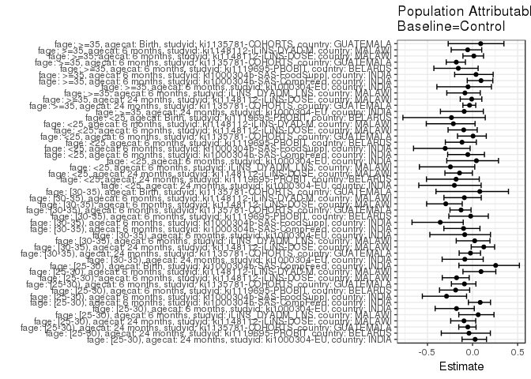

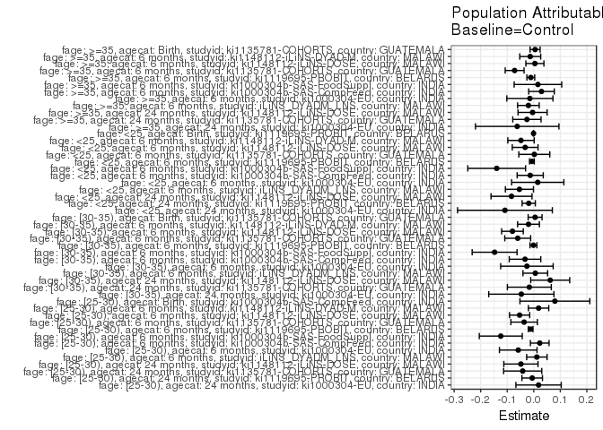

## Results Table

### Parameter: TSM

| fage | agecat | studyid | country | intervention_level | baseline_level | estimate | ci_lower | ci_upper |
| --- | --- | --- | --- | --- | --- | --- | --- | --- |
| >=35 | Birth | ki1135781-COHORTS | GUATEMALA | Control | NA | 0.0516129 | 0.0354734 | 0.0677524 |
| >=35 | Birth | ki1135781-COHORTS | GUATEMALA | Other | NA | 0.0611111 | 0.0422809 | 0.0799414 |
| >=35 | 6 months | iLiNS_DYADM_LNS | MALAWI | Control | NA | 0.2600000 | 0.2160251 | 0.3039749 |
| >=35 | 6 months | iLiNS_DYADM_LNS | MALAWI | LNS | NA | 0.2187500 | 0.1781424 | 0.2593576 |
| >=35 | 6 months | ki1000304-EU | INDIA | Control | NA | 0.3055556 | 0.1536949 | 0.4574162 |
| >=35 | 6 months | ki1000304-EU | INDIA | Zinc | NA | 0.2631579 | 0.0633323 | 0.4629835 |
| >=35 | 6 months | ki1000304b-SAS-CompFeed | INDIA | Control | NA | 0.2800000 | 0.2356396 | 0.3243604 |
| >=35 | 6 months | ki1000304b-SAS-CompFeed | INDIA | Other | NA | 0.3333333 | 0.2914784 | 0.3751883 |
| >=35 | 6 months | ki1000304b-SAS-FoodSuppl | INDIA | Control | NA | 0.3913043 | 0.3376493 | 0.4449594 |
| >=35 | 6 months | ki1000304b-SAS-FoodSuppl | INDIA | Other | NA | 0.4126984 | 0.3231193 | 0.5022775 |
| >=35 | 6 months | ki1119695-PROBIT | BELARUS | Control | NA | 0.0821114 | 0.0660530 | 0.0981699 |
| >=35 | 6 months | ki1119695-PROBIT | BELARUS | Maternal | NA | 0.0602241 | 0.0464291 | 0.0740191 |
| >=35 | 6 months | ki1135781-COHORTS | GUATEMALA | Control | NA | 0.4715909 | 0.4362713 | 0.5069105 |
| >=35 | 6 months | ki1135781-COHORTS | GUATEMALA | Other | NA | 0.3333333 | 0.2984968 | 0.3681699 |
| >=35 | 6 months | ki1148112-iLiNS-DOSE | MALAWI | Control | NA | 0.2900000 | 0.2744109 | 0.3055891 |
| >=35 | 6 months | ki1148112-iLiNS-DOSE | MALAWI | LNS | NA | 0.2951168 | 0.2611105 | 0.3291230 |
| >=35 | 6 months | ki1148112-iLiNS-DYAD-M | MALAWI | Control | NA | 0.2600000 | 0.2316735 | 0.2883265 |
| >=35 | 6 months | ki1148112-iLiNS-DYAD-M | MALAWI | Maternal | NA | 0.2401961 | 0.2007922 | 0.2795999 |
| >=35 | 24 months | ki1000304-EU | INDIA | Control | NA | 0.7368421 | 0.5364981 | 0.9371861 |
| >=35 | 24 months | ki1000304-EU | INDIA | Zinc | NA | 0.6250000 | 0.4290218 | 0.8209782 |
| >=35 | 24 months | ki1135781-COHORTS | GUATEMALA | Control | NA | 0.8000000 | 0.7488199 | 0.8511801 |
| >=35 | 24 months | ki1135781-COHORTS | GUATEMALA | Other | NA | 0.7457627 | 0.6926827 | 0.7988427 |
| >=35 | 24 months | ki1148112-iLiNS-DOSE | MALAWI | Control | NA | 0.4680851 | 0.4423472 | 0.4938230 |
| >=35 | 24 months | ki1148112-iLiNS-DOSE | MALAWI | LNS | NA | 0.4626168 | 0.4077385 | 0.5174951 |
| <25 | Birth | ki1119695-PROBIT | BELARUS | Control | NA | 0.0041978 | 0.0010451 | 0.0073504 |
| <25 | Birth | ki1119695-PROBIT | BELARUS | Maternal | NA | 0.0026490 | 0.0016365 | 0.0036615 |
| <25 | 6 months | iLiNS_DYADM_LNS | MALAWI | Control | NA | 0.2745098 | 0.2251310 | 0.3238886 |
| <25 | 6 months | iLiNS_DYADM_LNS | MALAWI | LNS | NA | 0.1842105 | 0.1318488 | 0.2365723 |
| <25 | 6 months | ki1000304-EU | INDIA | Control | NA | 0.3333333 | 0.1948207 | 0.4718459 |
| <25 | 6 months | ki1000304-EU | INDIA | Zinc | NA | 0.3636364 | 0.2206937 | 0.5065790 |

[output cut: 68 more lines]

### Parameter: E(Y)

| fage | agecat | studyid | country | intervention_level | baseline_level | estimate | ci_lower | ci_upper |
| --- | --- | --- | --- | --- | --- | --- | --- | --- |
| >=35 | Birth | ki1135781-COHORTS | GUATEMALA | NA | NA | 0.0567164 | 0.0319108 | 0.0815221 |
| >=35 | 6 months | iLiNS_DYADM_LNS | MALAWI | NA | NA | 0.2397959 | 0.1798697 | 0.2997221 |
| >=35 | 6 months | ki1000304-EU | INDIA | NA | NA | 0.2909091 | 0.1697710 | 0.4120472 |
| >=35 | 6 months | ki1000304b-SAS-CompFeed | INDIA | NA | NA | 0.3090909 | 0.2416294 | 0.3765525 |
| >=35 | 6 months | ki1000304b-SAS-FoodSuppl | INDIA | NA | NA | 0.4069767 | 0.3025386 | 0.5114149 |
| >=35 | 6 months | ki1119695-PROBIT | BELARUS | NA | NA | 0.0709169 | 0.0490128 | 0.0928210 |
| >=35 | 6 months | ki1135781-COHORTS | GUATEMALA | NA | NA | 0.3994565 | 0.3493468 | 0.4495662 |
| >=35 | 6 months | ki1148112-iLiNS-DOSE | MALAWI | NA | NA | 0.2942207 | 0.2568112 | 0.3316301 |
| >=35 | 6 months | ki1148112-iLiNS-DYAD-M | MALAWI | NA | NA | 0.2467105 | 0.1981703 | 0.2952507 |
| >=35 | 24 months | ki1000304-EU | INDIA | NA | NA | 0.6744186 | 0.5327029 | 0.8161343 |
| >=35 | 24 months | ki1135781-COHORTS | GUATEMALA | NA | NA | 0.7741935 | 0.7003031 | 0.8480840 |
| >=35 | 24 months | ki1148112-iLiNS-DOSE | MALAWI | NA | NA | 0.4636015 | 0.4029869 | 0.5242162 |
| <25 | Birth | ki1119695-PROBIT | BELARUS | NA | NA | 0.0034021 | 0.0000492 | 0.0067551 |
| <25 | 6 months | iLiNS_DYADM_LNS | MALAWI | NA | NA | 0.2204724 | 0.1480863 | 0.2928586 |
| <25 | 6 months | ki1000304-EU | INDIA | NA | NA | 0.3483146 | 0.2487714 | 0.4478578 |
| <25 | 6 months | ki1000304b-SAS-CompFeed | INDIA | NA | NA | 0.2558140 | 0.1975358 | 0.3140921 |
| <25 | 6 months | ki1000304b-SAS-FoodSuppl | INDIA | NA | NA | 0.4603175 | 0.3362522 | 0.5843827 |
| <25 | 6 months | ki1119695-PROBIT | BELARUS | NA | NA | 0.0593870 | 0.0427849 | 0.0759890 |
| <25 | 6 months | ki1135781-COHORTS | GUATEMALA | NA | NA | 0.3656716 | 0.2838205 | 0.4475228 |
| <25 | 6 months | ki1148112-iLiNS-DOSE | MALAWI | NA | NA | 0.3311688 | 0.2785233 | 0.3838144 |
| <25 | 6 months | ki1148112-iLiNS-DYAD-M | MALAWI | NA | NA | 0.2263158 | 0.1666595 | 0.2859721 |
| <25 | 24 months | ki1000304-EU | INDIA | NA | NA | 0.5384615 | 0.3799585 | 0.6969646 |
| <25 | 24 months | ki1119695-PROBIT | BELARUS | NA | NA | 0.1037037 | 0.0555155 | 0.1518919 |
| <25 | 24 months | ki1148112-iLiNS-DOSE | MALAWI | NA | NA | 0.5827338 | 0.5004622 | 0.6650055 |
| [25-30) | Birth | ki1000304b-SAS-CompFeed | INDIA | NA | NA | 0.3103448 | 0.1480972 | 0.4725924 |
| [25-30) | 6 months | iLiNS_DYADM_LNS | MALAWI | NA | NA | 0.1864407 | 0.1289024 | 0.2439789 |
| [25-30) | 6 months | ki1000304-EU | INDIA | NA | NA | 0.3289474 | 0.2540095 | 0.4038852 |
| [25-30) | 6 months | ki1000304b-SAS-CompFeed | INDIA | NA | NA | 0.2651515 | 0.2135475 | 0.3167556 |
| [25-30) | 6 months | ki1000304b-SAS-FoodSuppl | INDIA | NA | NA | 0.4311927 | 0.3377910 | 0.5245943 |
| [25-30) | 6 months | ki1119695-PROBIT | BELARUS | NA | NA | 0.0631198 | 0.0486839 | 0.0775556 |
| [25-30) | 6 months | ki1135781-COHORTS | GUATEMALA | NA | NA | 0.4032258 | 0.3325385 | 0.4739131 |
| [25-30) | 6 months | ki1148112-iLiNS-DOSE | MALAWI | NA | NA | 0.3010989 | 0.2589018 | 0.3432960 |
| [25-30) | 6 months | ki1148112-iLiNS-DYAD-M | MALAWI | NA | NA | 0.1929134 | 0.1442918 | 0.2415350 |
| [25-30) | 24 months | ki1000304-EU | INDIA | NA | NA | 0.6320755 | 0.5398359 | 0.7243150 |
| [25-30) | 24 months | ki1119695-PROBIT | BELARUS | NA | NA | 0.1495017 | 0.0876193 | 0.2113841 |
| [25-30) | 24 months | ki1135781-COHORTS | GUATEMALA | NA | NA | 0.7916667 | 0.6972020 | 0.8861314 |
| [25-30) | 24 months | ki1148112-iLiNS-DOSE | MALAWI | NA | NA | 0.5104167 | 0.4395230 | 0.5813103 |
| [30-35) | Birth | ki1135781-COHORTS | GUATEMALA | NA | NA | 0.0617978 | 0.0263249 | 0.0972706 |
| [30-35) | 6 months | iLiNS_DYADM_LNS | MALAWI | NA | NA | 0.2439024 | 0.1779773 | 0.3098276 |
| [30-35) | 6 months | ki1000304-EU | INDIA | NA | NA | 0.2985075 | 0.1881084 | 0.4089065 |
| [30-35) | 6 months | ki1000304b-SAS-CompFeed | INDIA | NA | NA | 0.3306452 | 0.2296543 | 0.4316360 |
| [30-35) | 6 months | ki1000304b-SAS-FoodSuppl | INDIA | NA | NA | 0.4123711 | 0.3139002 | 0.5108421 |
| [30-35) | 6 months | ki1119695-PROBIT | BELARUS | NA | NA | 0.0611238 | 0.0435086 | 0.0787389 |
| [30-35) | 6 months | ki1135781-COHORTS | GUATEMALA | NA | NA | 0.4741784 | 0.4069628 | 0.5413940 |
| [30-35) | 6 months | ki1148112-iLiNS-DOSE | MALAWI | NA | NA | 0.2705570 | 0.2256536 | 0.3154604 |
| [30-35) | 6 months | ki1148112-iLiNS-DYAD-M | MALAWI | NA | NA | 0.2182540 | 0.1671535 | 0.2693545 |
| [30-35) | 24 months | ki1000304-EU | INDIA | NA | NA | 0.5468750 | 0.4239526 | 0.6697974 |
| [30-35) | 24 months | ki1135781-COHORTS | GUATEMALA | NA | NA | 0.7166667 | 0.6016848 | 0.8316486 |
| [30-35) | 24 months | ki1148112-iLiNS-DOSE | MALAWI | NA | NA | 0.4967320 | 0.4172467 | 0.5762174 |

### Parameter: RR

| fage | agecat | studyid | country | intervention_level | baseline_level | estimate | ci_lower | ci_upper |
| --- | --- | --- | --- | --- | --- | --- | --- | --- |
| >=35 | Birth | ki1135781-COHORTS | GUATEMALA | Control | Control | 1.0000000 | 1.0000000 | 1.0000000 |
| >=35 | Birth | ki1135781-COHORTS | GUATEMALA | Other | Control | 1.1840278 | 0.7633139 | 1.8366256 |
| >=35 | 6 months | iLiNS_DYADM_LNS | MALAWI | Control | Control | 1.0000000 | 1.0000000 | 1.0000000 |
| >=35 | 6 months | iLiNS_DYADM_LNS | MALAWI | LNS | Control | 0.8413462 | 0.6545005 | 1.0815322 |
| >=35 | 6 months | ki1000304-EU | INDIA | Control | Control | 1.0000000 | 1.0000000 | 1.0000000 |
| >=35 | 6 months | ki1000304-EU | INDIA | Zinc | Control | 0.8612440 | 0.3475308 | 2.1343178 |
| >=35 | 6 months | ki1000304b-SAS-CompFeed | INDIA | Control | Control | 1.0000000 | 1.0000000 | 1.0000000 |
| >=35 | 6 months | ki1000304b-SAS-CompFeed | INDIA | Other | Control | 1.1904762 | 0.9738518 | 1.4552867 |
| >=35 | 6 months | ki1000304b-SAS-FoodSuppl | INDIA | Control | Control | 1.0000000 | 1.0000000 | 1.0000000 |
| >=35 | 6 months | ki1000304b-SAS-FoodSuppl | INDIA | Other | Control | 1.0546737 | 0.8158635 | 1.3633857 |
| >=35 | 6 months | ki1119695-PROBIT | BELARUS | Control | Control | 1.0000000 | 1.0000000 | 1.0000000 |
| >=35 | 6 months | ki1119695-PROBIT | BELARUS | Maternal | Control | 0.7334434 | 0.5429382 | 0.9907926 |
| >=35 | 6 months | ki1135781-COHORTS | GUATEMALA | Control | Control | 1.0000000 | 1.0000000 | 1.0000000 |
| >=35 | 6 months | ki1135781-COHORTS | GUATEMALA | Other | Control | 0.7068273 | 0.6215470 | 0.8038086 |
| >=35 | 6 months | ki1148112-iLiNS-DOSE | MALAWI | Control | Control | 1.0000000 | 1.0000000 | 1.0000000 |
| >=35 | 6 months | ki1148112-iLiNS-DOSE | MALAWI | LNS | Control | 1.0176440 | 0.8961374 | 1.1556257 |
| >=35 | 6 months | ki1148112-iLiNS-DYAD-M | MALAWI | Control | Control | 1.0000000 | 1.0000000 | 1.0000000 |
| >=35 | 6 months | ki1148112-iLiNS-DYAD-M | MALAWI | Maternal | Control | 0.9238311 | 0.7586941 | 1.1249117 |
| >=35 | 24 months | ki1000304-EU | INDIA | Control | Control | 1.0000000 | 1.0000000 | 1.0000000 |
| >=35 | 24 months | ki1000304-EU | INDIA | Zinc | Control | 0.8482143 | 0.5600931 | 1.2845498 |
| >=35 | 24 months | ki1135781-COHORTS | GUATEMALA | Control | Control | 1.0000000 | 1.0000000 | 1.0000000 |
| >=35 | 24 months | ki1135781-COHORTS | GUATEMALA | Other | Control | 0.9322034 | 0.8471261 | 1.0258250 |
| >=35 | 24 months | ki1148112-iLiNS-DOSE | MALAWI | Control | Control | 1.0000000 | 1.0000000 | 1.0000000 |
| >=35 | 24 months | ki1148112-iLiNS-DOSE | MALAWI | LNS | Control | 0.9883178 | 0.8671869 | 1.1263685 |
| <25 | Birth | ki1119695-PROBIT | BELARUS | Control | Control | 1.0000000 | 1.0000000 | 1.0000000 |
| <25 | Birth | ki1119695-PROBIT | BELARUS | Maternal | Control | 0.6310523 | 0.2720561 | 1.4637680 |
| <25 | 6 months | iLiNS_DYADM_LNS | MALAWI | Control | Control | 1.0000000 | 1.0000000 | 1.0000000 |
| <25 | 6 months | iLiNS_DYADM_LNS | MALAWI | LNS | Control | 0.6710526 | 0.4793654 | 0.9393913 |
| <25 | 6 months | ki1000304-EU | INDIA | Control | Control | 1.0000000 | 1.0000000 | 1.0000000 |
| <25 | 6 months | ki1000304-EU | INDIA | Zinc | Control | 1.0909091 | 0.6156993 | 1.9328959 |

[output cut: 68 more lines]

### Parameter: PAR

| fage | agecat | studyid | country | intervention_level | baseline_level | estimate | ci_lower | ci_upper |
| --- | --- | --- | --- | --- | --- | --- | --- | --- |
| >=35 | Birth | ki1135781-COHORTS | GUATEMALA | Control | NA | 0.0051035 | -0.0137336 | 0.0239406 |
| >=35 | 6 months | iLiNS_DYADM_LNS | MALAWI | Control | NA | -0.0202041 | -0.0609147 | 0.0205065 |
| >=35 | 6 months | ki1000304-EU | INDIA | Control | NA | -0.0146465 | -0.1015159 | 0.0722230 |
| >=35 | 6 months | ki1000304b-SAS-CompFeed | INDIA | Control | NA | 0.0290909 | -0.0191575 | 0.0773393 |
| >=35 | 6 months | ki1000304b-SAS-FoodSuppl | INDIA | Control | NA | 0.0156724 | -0.0739293 | 0.1052741 |
| >=35 | 6 months | ki1119695-PROBIT | BELARUS | Control | NA | -0.0111945 | -0.0259308 | 0.0035418 |
| >=35 | 6 months | ki1135781-COHORTS | GUATEMALA | Control | NA | -0.0721344 | -0.1076803 | -0.0365885 |
| >=35 | 6 months | ki1148112-iLiNS-DOSE | MALAWI | Control | NA | 0.0042207 | -0.0297859 | 0.0382273 |
| >=35 | 6 months | ki1148112-iLiNS-DYAD-M | MALAWI | Control | NA | -0.0132895 | -0.0527073 | 0.0261283 |
| >=35 | 24 months | ki1000304-EU | INDIA | Control | NA | -0.0624235 | -0.2197465 | 0.0948995 |
| >=35 | 24 months | ki1135781-COHORTS | GUATEMALA | Control | NA | -0.0258065 | -0.0791018 | 0.0274889 |
| >=35 | 24 months | ki1148112-iLiNS-DOSE | MALAWI | Control | NA | -0.0044836 | -0.0593625 | 0.0503953 |
| <25 | Birth | ki1119695-PROBIT | BELARUS | Control | NA | -0.0007956 | -0.0018573 | 0.0002660 |
| <25 | 6 months | iLiNS_DYADM_LNS | MALAWI | Control | NA | -0.0540374 | -0.1069665 | -0.0011082 |
| <25 | 6 months | ki1000304-EU | INDIA | Control | NA | 0.0149813 | -0.0834732 | 0.1134357 |
| <25 | 6 months | ki1000304b-SAS-CompFeed | INDIA | Control | NA | -0.0134168 | -0.0626832 | 0.0358496 |
| <25 | 6 months | ki1000304b-SAS-FoodSuppl | INDIA | Control | NA | -0.1396825 | -0.2485479 | -0.0308172 |
| <25 | 6 months | ki1119695-PROBIT | BELARUS | Control | NA | -0.0069284 | -0.0158327 | 0.0019760 |
| <25 | 6 months | ki1135781-COHORTS | GUATEMALA | Control | NA | 0.0020353 | -0.0563397 | 0.0604103 |
| <25 | 6 months | ki1148112-iLiNS-DOSE | MALAWI | Control | NA | -0.0324675 | -0.0810258 | 0.0160908 |
| <25 | 6 months | ki1148112-iLiNS-DYAD-M | MALAWI | Control | NA | -0.0481940 | -0.0979167 | 0.0015287 |
| <25 | 24 months | ki1000304-EU | INDIA | Control | NA | -0.1085973 | -0.2872404 | 0.0700458 |
| <25 | 24 months | ki1119695-PROBIT | BELARUS | Control | NA | -0.0189378 | -0.0438258 | 0.0059502 |
| <25 | 24 months | ki1148112-iLiNS-DOSE | MALAWI | Control | NA | -0.0839329 | -0.1611829 | -0.0066828 |
| [25-30) | Birth | ki1000304b-SAS-CompFeed | INDIA | Control | NA | 0.0795756 | -0.0521389 | 0.2112901 |
| [25-30) | 6 months | iLiNS_DYADM_LNS | MALAWI | Control | NA | 0.0116834 | -0.0267732 | 0.0501400 |
| [25-30) | 6 months | ki1000304-EU | INDIA | Control | NA | -0.0585526 | -0.1293472 | 0.0122420 |
| [25-30) | 6 months | ki1000304b-SAS-CompFeed | INDIA | Control | NA | 0.0225045 | -0.0127012 | 0.0577101 |
| [25-30) | 6 months | ki1000304b-SAS-FoodSuppl | INDIA | Control | NA | -0.1243629 | -0.2052850 | -0.0434408 |
| [25-30) | 6 months | ki1119695-PROBIT | BELARUS | Control | NA | -0.0118217 | -0.0204513 | -0.0031921 |
| [25-30) | 6 months | ki1135781-COHORTS | GUATEMALA | Control | NA | -0.0363346 | -0.0862750 | 0.0136058 |
| [25-30) | 6 months | ki1148112-iLiNS-DOSE | MALAWI | Control | NA | -0.0533315 | -0.0913374 | -0.0153256 |
| [25-30) | 6 months | ki1148112-iLiNS-DYAD-M | MALAWI | Control | NA | 0.0181561 | -0.0202638 | 0.0565761 |
| [25-30) | 24 months | ki1000304-EU | INDIA | Control | NA | 0.0180404 | -0.0673482 | 0.1034290 |
| [25-30) | 24 months | ki1119695-PROBIT | BELARUS | Control | NA | -0.0059037 | -0.0445907 | 0.0327832 |
| [25-30) | 24 months | ki1135781-COHORTS | GUATEMALA | Control | NA | -0.0416667 | -0.1135435 | 0.0302102 |
| [25-30) | 24 months | ki1148112-iLiNS-DOSE | MALAWI | Control | NA | -0.0484069 | -0.1128106 | 0.0159969 |
| [30-35) | Birth | ki1135781-COHORTS | GUATEMALA | Control | NA | 0.0049796 | -0.0211609 | 0.0311200 |
| [30-35) | 6 months | iLiNS_DYADM_LNS | MALAWI | Control | NA | 0.0058072 | -0.0406296 | 0.0522440 |
| [30-35) | 6 months | ki1000304-EU | INDIA | Control | NA | -0.0258169 | -0.1246849 | 0.0730512 |
| [30-35) | 6 months | ki1000304b-SAS-CompFeed | INDIA | Control | NA | -0.0329912 | -0.0923902 | 0.0264078 |
| [30-35) | 6 months | ki1000304b-SAS-FoodSuppl | INDIA | Control | NA | -0.1476289 | -0.2322182 | -0.0630395 |
| [30-35) | 6 months | ki1119695-PROBIT | BELARUS | Control | NA | -0.0012811 | -0.0142780 | 0.0117158 |
| [30-35) | 6 months | ki1135781-COHORTS | GUATEMALA | Control | NA | -0.0604751 | -0.1092626 | -0.0116876 |
| [30-35) | 6 months | ki1148112-iLiNS-DOSE | MALAWI | Control | NA | -0.0803202 | -0.1211184 | -0.0395220 |
| [30-35) | 6 months | ki1148112-iLiNS-DYAD-M | MALAWI | Control | NA | -0.0198413 | -0.0608999 | 0.0212174 |
| [30-35) | 24 months | ki1000304-EU | INDIA | Control | NA | -0.0468750 | -0.1697974 | 0.0760474 |
| [30-35) | 24 months | ki1135781-COHORTS | GUATEMALA | Control | NA | -0.0166667 | -0.0994591 | 0.0661257 |
| [30-35) | 24 months | ki1148112-iLiNS-DOSE | MALAWI | Control | NA | 0.0619494 | -0.0114283 | 0.1353271 |

### Parameter: PAF

| fage | agecat | studyid | country | intervention_level | baseline_level | estimate | ci_lower | ci_upper |
| --- | --- | --- | --- | --- | --- | --- | --- | --- |
| >=35 | Birth | ki1135781-COHORTS | GUATEMALA | Control | NA | 0.0899830 | -0.2700108 | 0.3479340 |
| >=35 | 6 months | iLiNS_DYADM_LNS | MALAWI | Control | NA | -0.0842553 | -0.2856474 | 0.0855894 |
| >=35 | 6 months | ki1000304-EU | INDIA | Control | NA | -0.0503472 | -0.3955993 | 0.2094942 |
| >=35 | 6 months | ki1000304b-SAS-CompFeed | INDIA | Control | NA | 0.0941176 | -0.0587350 | 0.2249025 |
| >=35 | 6 months | ki1000304b-SAS-FoodSuppl | INDIA | Control | NA | 0.0385093 | -0.1983638 | 0.2285612 |
| >=35 | 6 months | ki1119695-PROBIT | BELARUS | Control | NA | -0.1578542 | -0.4289681 | 0.0618221 |
| >=35 | 6 months | ki1135781-COHORTS | GUATEMALA | Control | NA | -0.1805813 | -0.2917716 | -0.0789619 |
| >=35 | 6 months | ki1148112-iLiNS-DOSE | MALAWI | Control | NA | 0.0143452 | -0.1064265 | 0.1219342 |
| >=35 | 6 months | ki1148112-iLiNS-DYAD-M | MALAWI | Control | NA | -0.0538667 | -0.2365770 | 0.1018473 |
| >=35 | 24 months | ki1000304-EU | INDIA | Control | NA | -0.0925590 | -0.3561279 | 0.1197843 |
| >=35 | 24 months | ki1135781-COHORTS | GUATEMALA | Control | NA | -0.0333333 | -0.1070100 | 0.0354398 |
| >=35 | 24 months | ki1148112-iLiNS-DOSE | MALAWI | Control | NA | -0.0096712 | -0.1365542 | 0.1030469 |
| <25 | Birth | ki1119695-PROBIT | BELARUS | Control | NA | -0.2338619 | -0.7722253 | 0.1409584 |
| <25 | 6 months | iLiNS_DYADM_LNS | MALAWI | Control | NA | -0.2450980 | -0.5893107 | 0.0245651 |
| <25 | 6 months | ki1000304-EU | INDIA | Control | NA | 0.0430108 | -0.2858328 | 0.2877547 |
| <25 | 6 months | ki1000304b-SAS-CompFeed | INDIA | Control | NA | -0.0524476 | -0.2760890 | 0.1319995 |
| <25 | 6 months | ki1000304b-SAS-FoodSuppl | INDIA | Control | NA | -0.3034483 | -0.6543709 | -0.0269628 |
| <25 | 6 months | ki1119695-PROBIT | BELARUS | Control | NA | -0.1166645 | -0.3016412 | 0.0420250 |
| <25 | 6 months | ki1135781-COHORTS | GUATEMALA | Control | NA | 0.0055659 | -0.1665595 | 0.1522942 |
| <25 | 6 months | ki1148112-iLiNS-DOSE | MALAWI | Control | NA | -0.0980392 | -0.2715740 | 0.0518129 |
| <25 | 6 months | ki1148112-iLiNS-DYAD-M | MALAWI | Control | NA | -0.2129503 | -0.5132260 | 0.0277404 |
| <25 | 24 months | ki1000304-EU | INDIA | Control | NA | -0.2016807 | -0.5962670 | 0.0953666 |
| <25 | 24 months | ki1119695-PROBIT | BELARUS | Control | NA | -0.1826146 | -0.5112140 | 0.0745340 |
| <25 | 24 months | ki1148112-iLiNS-DOSE | MALAWI | Control | NA | -0.1440329 | -0.3063873 | -0.0018555 |
| [25-30) | Birth | ki1000304b-SAS-CompFeed | INDIA | Control | NA | 0.2564103 | -0.1511585 | 0.5196789 |
| [25-30) | 6 months | iLiNS_DYADM_LNS | MALAWI | Control | NA | 0.0626655 | -0.1527175 | 0.2378046 |
| [25-30) | 6 months | ki1000304-EU | INDIA | Control | NA | -0.1780000 | -0.4148386 | 0.0191927 |
| [25-30) | 6 months | ki1000304b-SAS-CompFeed | INDIA | Control | NA | 0.0848739 | -0.0460025 | 0.1993750 |
| [25-30) | 6 months | ki1000304b-SAS-FoodSuppl | INDIA | Control | NA | -0.2884161 | -0.5568113 | -0.0662923 |
| [25-30) | 6 months | ki1119695-PROBIT | BELARUS | Control | NA | -0.1872900 | -0.3662395 | -0.0317791 |
| [25-30) | 6 months | ki1135781-COHORTS | GUATEMALA | Control | NA | -0.0901099 | -0.2343624 | 0.0372847 |
| [25-30) | 6 months | ki1148112-iLiNS-DOSE | MALAWI | Control | NA | -0.1771228 | -0.3359320 | -0.0371920 |
| [25-30) | 6 months | ki1148112-iLiNS-DYAD-M | MALAWI | Control | NA | 0.0941153 | -0.1062310 | 0.2581775 |
| [25-30) | 24 months | ki1000304-EU | INDIA | Control | NA | 0.0285415 | -0.1165674 | 0.1547921 |
| [25-30) | 24 months | ki1119695-PROBIT | BELARUS | Control | NA | -0.0394895 | -0.3467554 | 0.1976728 |
| [25-30) | 24 months | ki1135781-COHORTS | GUATEMALA | Control | NA | -0.0526316 | -0.1527698 | 0.0388079 |
| [25-30) | 24 months | ki1148112-iLiNS-DOSE | MALAWI | Control | NA | -0.0948379 | -0.2422015 | 0.0350438 |
| [30-35) | Birth | ki1135781-COHORTS | GUATEMALA | Control | NA | 0.0805785 | -0.4054448 | 0.3985279 |
| [30-35) | 6 months | iLiNS_DYADM_LNS | MALAWI | Control | NA | 0.0238095 | -0.1809872 | 0.1930922 |
| [30-35) | 6 months | ki1000304-EU | INDIA | Control | NA | -0.0864865 | -0.4735658 | 0.1989140 |
| [30-35) | 6 months | ki1000304b-SAS-CompFeed | INDIA | Control | NA | -0.0997783 | -0.3179651 | 0.0822881 |
| [30-35) | 6 months | ki1000304b-SAS-FoodSuppl | INDIA | Control | NA | -0.3580000 | -0.6713943 | -0.1033686 |
| [30-35) | 6 months | ki1119695-PROBIT | BELARUS | Control | NA | -0.0209592 | -0.2629747 | 0.1746805 |
| [30-35) | 6 months | ki1135781-COHORTS | GUATEMALA | Control | NA | -0.1275365 | -0.2504620 | -0.0166951 |
| [30-35) | 6 months | ki1148112-iLiNS-DOSE | MALAWI | Control | NA | -0.2968696 | -0.5091997 | -0.1144124 |
| [30-35) | 6 months | ki1148112-iLiNS-DYAD-M | MALAWI | Control | NA | -0.0909091 | -0.3171797 | 0.0964918 |
| [30-35) | 24 months | ki1000304-EU | INDIA | Control | NA | -0.0857143 | -0.3370880 | 0.1184010 |
| [30-35) | 24 months | ki1135781-COHORTS | GUATEMALA | Control | NA | -0.0232558 | -0.1485973 | 0.0884077 |
| [30-35) | 24 months | ki1148112-iLiNS-DOSE | MALAWI | Control | NA | 0.1247140 | -0.0148858 | 0.2451115 |